# Count Models: Poisson versus Negative Binomial Regression

Babak RezaeeDaryakenari[^1], Sabanci University

Spring 2019

# Count data

Some political outcomes only take non-negative integer values, $Y \in \mathbb{Z}^+$. For example, the number of civilians killed daily/weekly/monthly/yearly in a civil war; number of female candidate at every election; the number of terrorist attacks within a time period. King(1988) shows that estimating a model with count outcomes using OLS leads to

- nonsensical predictions (negative predicted counts)
- Heteroskedasticity and thus inefficient standard errors

Thus, do not use OLS for count models, though labor economists have a different view (Angrist & Pischke 2009).

These types of outcomes are often modeled using a Poisson distribution, $Y \sim Poisson(\lambda)$. Parameter $\lambda$ here simply present the expected number of occurrences. Does $\lambda$ need to be an integer value?

The probability function of Poisson distribution is:

$$\begin{equation}
Poisson(\lambda)=\frac{\lambda^k e^{-\lambda}}{k!}
\end{equation}$$

The mean and variance of this distribution are $\lambda>0$. There is a straightforward interpretation for $\lambda$: the expected number of events in any particular time period t. Poisson distribution is a memoriless distribution; that is, the occurrence of an event is independent.

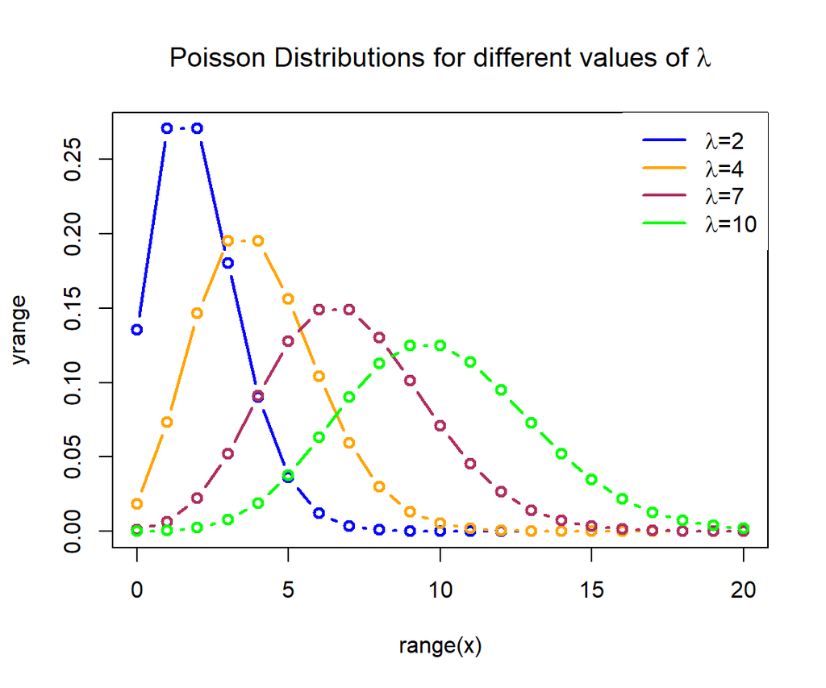

```r
x = 0:20;  pdf = dpois(x, 4)


yrange <- range(dpois(x, 2),dpois(x, 4),dpois(x, 7))

plot(range(x), yrange, type="n", lwd=3, col="blue",
     main=TeX('Poisson Distributions for different values of $\\lambda$'))

lines(x, dpois(x, 2), type="b", lwd=2, col='blue')

lines(x, dpois(x, 4), type="b", lwd=2, col='orange')

lines(x, dpois(x, 7), type="b", lwd=2, col='maroon')

lines(x, dpois(x, 10), type="b", lwd=2, col='green')

legend("topright", legend=c(TeX('$\\lambda$=2'),
                            TeX('$\\lambda$=4'),
                            TeX('$\\lambda$=7'),
                           TeX('$\\lambda$=10')),
       col=c("blue","orange","maroon","green"),
       lty=1, box.lty=0, cex=1,lwd=2)
```

# Generalized Linear Models (GLM)

GLM method extend the linear estimation method to variables that are not normally distributed. Although GLM helps us to model non-linear outcomes, it is made up of a linear estimation:

$$\begin{equation}
\eta_i=\beta_0+\beta_1x_{1i}+\dots+\beta_px_{pi}
\end{equation}$$

and two functions:

- a *link* function that transforms the above linear estimation to the mean of a non-normal distribution, $E(Y_i)=\lambda$:

$$\begin{align}
g(\lambda)=\eta_i \\
E(Y_i)=\lambda=g^{-1}(\eta_i)
\end{align}$$

- a *variance* function that describes how the variance of outcome is associated with the variance of mean:

$$\begin{equation}
var(Y_i)=\phi V(\lambda)=V(g^{-1}(\eta_i))
\end{equation}$$

where $\phi$ is a constant parameter that measures dispersion.

# Estimation using MLE

The likelihood function of a Poisson distribution, assuming that $log(\lambda_i)=x_i' \beta \equiv \lambda_i=exp(x_i' \beta)$, can be written as follow:

$$\begin{align}
P(\lambda|Y)=\prod_{i=1}^{N}\frac{e^{-\lambda} \lambda^Y}{Y!} \\
ln L(\lambda|Y)=ln[\prod_{i=1}^{N} \frac{e^{-e^{X\beta}}e^{(X\beta) Y}}{Y!}]
\end{align}$$

We can re-arrange the above equation:

$$\begin{align}
ln L(\lambda|Y)=\sum_{i=1}^N [-e^{X\beta}+Y(X\beta)-log(Y!)]
\end{align}$$

This maximum likelihood model can be estimated fairly easy by numerical optimization of the above likelihood model.

The signs of the vector $beta$ indicate the effect of $X$ on $\lambda$:

- Positive signs indicate a positive effect
- Negative signs indicate a negative effect

The above link function/log-transformation resolves the problem of negative predicted values. Cameron and Trivedi (2005) also recommend using robust standard errors to correct for heteroskedasticity when we use Poisson model for estimation.

# Estimation with no predictor

Here, we use the data from “Armed intervention and civilian victimization in intrastate conflicts” by Wood, Kathman, and Gent. The full replication data is available here: https://www.prio.org/JPR/Datasets

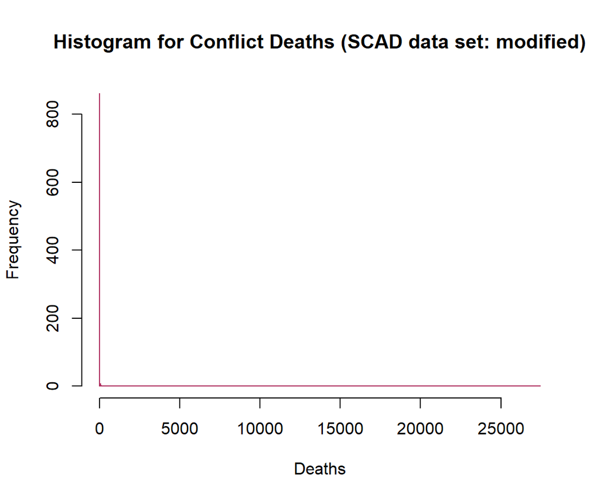

```r
WKGdata=read.csv("https://raw.githubusercontent.com/babakrezaee/MethodsCourses/master/DataSets/WKG_JPR_2012.csv")


hist(WKGdata$rebbest2010,  col="grey", border="maroon",
     main="Histogram for Conflict Deaths (SCAD data set: modified)",
     xlab="Deaths",
     breaks = 0:summary(WKGdata$rebbest2010)[6])
```

```r
library(glmnet)
poisson_ml <- glm(rebbest2010 ~ 1 , family="poisson", data=WKGdata)

summary(poisson_ml)
```

```
##
## Call:
## glm(formula = rebbest2010 ~ 1, family = "poisson", data = WKGdata)
##
## Deviance Residuals:
##    Min      1Q  Median      3Q     Max
## -12.77  -12.77  -12.77   -7.27  514.44
##
## Coefficients:
##             Estimate Std. Error z value Pr(>|z|)
## (Intercept) 4.401508   0.003252    1353   <2e-16 ***
## ---
## Signif. codes:  0 '***' 0.001 '**' 0.01 '*' 0.05 '.' 0.1 ' ' 1
##
## (Dispersion parameter for poisson family taken to be 1)
##
##     Null deviance: 596617  on 1158  degrees of freedom
## Residual deviance: 596617  on 1158  degrees of freedom
##   (7 observations deleted due to missingness)
## AIC: 598550
##
## Number of Fisher Scoring iterations: 8
```

```r
exp(poisson_ml$coefficients[[1]]+0)
```

```
## [1] 81.57377
```

```r
poissonModel <- glm(rebbest2010 ~ lnintv_ratiolag, family="poisson", data=WKGdata)

summary(poissonModel)
```

```
##
## Call:
## glm(formula = rebbest2010 ~ lnintv_ratiolag, family = "poisson",
##     data = WKGdata)
##
## Deviance Residuals:
##     Min       1Q   Median       3Q      Max
## -15.646  -11.286  -11.286   -3.631  254.864
##
## Coefficients:
##                  Estimate Std. Error z value Pr(>|z|)
## (Intercept)      4.153921   0.004455  932.50   <2e-16 ***
## lnintv_ratiolag -0.126376   0.003725  -33.92   <2e-16 ***
## ---
## Signif. codes:  0 '***' 0.001 '**' 0.01 '*' 0.05 '.' 0.1 ' ' 1
##
## (Dispersion parameter for poisson family taken to be 1)
##
##     Null deviance: 230394  on 824  degrees of freedom
## Residual deviance: 229372  on 823  degrees of freedom
##   (341 observations deleted due to missingness)
## AIC: 231038
##
## Number of Fisher Scoring iterations: 7
```

```r
exp(poissonModel$coefficients[[1]]+0)
```

```
## [1] 63.68323
```

```r
exp(poissonModel$coefficients[[1]]+poissonModel$coefficients[[2]]*1)
```

```
## [1] 56.12299
```

The results show that each unit of intervention decreases the average number of rebel violence against civilians by 7.5602458.

Here, $\beta=log(\lambda x+1)-log(\lambda x)$.

## Predicting from the estimated model

After estimating your Poisson regression, you can predict outcomes using any dataset containing the features used in the estimated model.

```r
newData=data.frame(lnintv_ratiolag=3)

predict(poissonModel,newdata = newData, type='response')
```

```
##        1
## 43.58852
```

## Visualizing findings

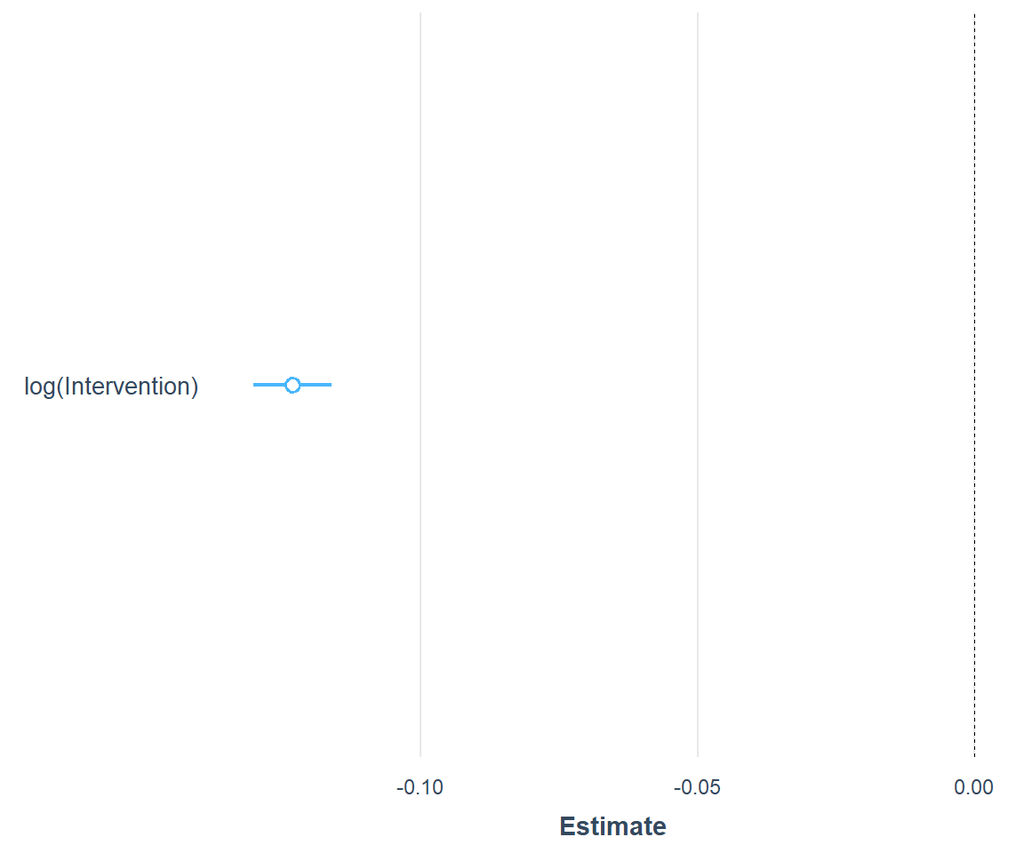

```r
library(jtools)

plot_summs(poissonModel, scale=TRUE, exp = FALSE,
           model.names = c("Poisson"),
           coefs = c("log(Intervention)" = "lnintv_ratiolag"))
```

We can also compare the coefficients of two models:

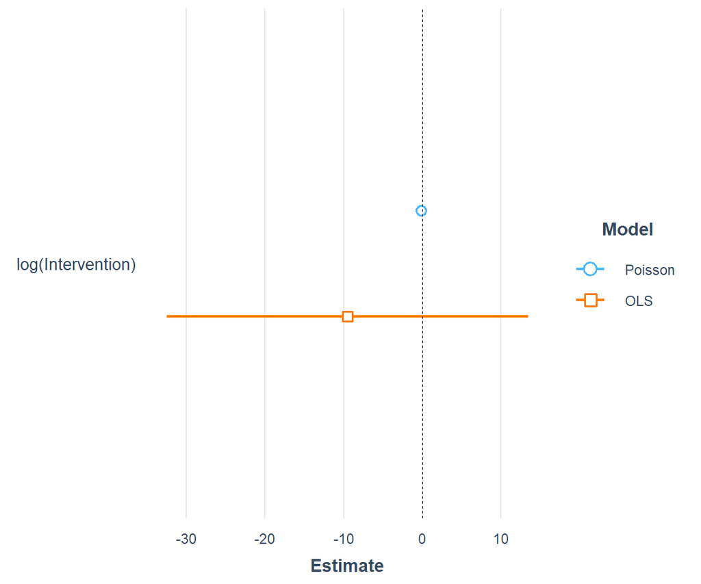

```r
linearModel <- lm(rebbest2010 ~ lnintv_ratiolag, data=WKGdata)


plot_summs(poissonModel,linearModel, scale=TRUE, exp = FALSE,
           model.names = c("Poisson","OLS"),
           coefs = c("log(Intervention)" = "lnintv_ratiolag"))
```

## Marginal effects in count models

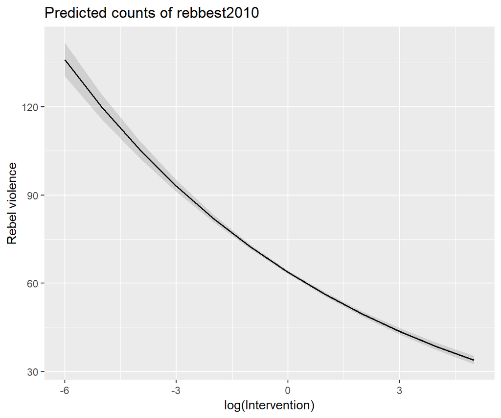

```r
library(sjPlot)
library(ggplot2)

plot_model(poissonModel, type = "pred", terms = "lnintv_ratiolag")+xlab('log(Intervention)')+ylab('Rebel violence')
```

See here for more info on plotting marginal effects: https://cran.r-project.org/web/packages/sjPlot/vignettes/plot_marginal_effects.html

To compute robust standard errors, as suggested by Cameron and Trivedi (2005), we can use ${\tt sandwich}$ library:

```r
poissonModel <- glm(rebbest2010 ~ lnintv_ratiolag, family="poisson", data=WKGdata)

library(sandwich)

cov.pois <- vcovHC(poissonModel, type="HC0")

# HC0 are White's correction

se <- sqrt(diag(cov.pois))

robust <- cbind(estimate=poissonModel$coefficients, se,
pvalue=round(2*(1-pnorm(abs(poissonModel$coefficients/se))),
5), lower=poissonModel$coefficients-1.96*se,
upper=poissonModel$coefficients+1.96*se)

robust
```

```
##                   estimate        se  pvalue      lower     upper
## (Intercept)      4.1539213 0.1943300 0.00000  3.7730345 4.5348082
## lnintv_ratiolag -0.1263758 0.1750579 0.47035 -0.4694894 0.2167377
```

# Negative Binomial Models

One of the major assumptions of Poisson distribution/model is that the mean and variance of the data are equal: $mean(Y)=Var(Y)=\lambda$

However, when we evaluate this assumption, it is rejected:

```r
mean(WKGdata$rebbest2010, na.rm=TRUE)
```

```
## [1] 81.57377
```

```r
var(WKGdata$rebbest2010,na.rm=TRUE)
```

```
## [1] 751373.2
```

When the variance is greater than the mean of the distribution, there is overdispersion. MLE is still consistent when there is overdispersion, but the estimates will be:

- Inefficient with downward biased standard errors
- Large Z-scores and false positives

Thus, we use a Negative Binomial MLE for overdispersed, and underdispersed, count data.

Question: what is an underdispersed distribution?

## How to test the overdispersion?

We can statistically test *dispersiontest* using $\mathcal{R}$ package ${\tt AER}$.

```r
library(AER)

poissonModel <- glm(rebbest2010 ~ lnintv_ratiolag, family="poisson", data=WKGdata)

dispersiontest(poissonModel,trafo=1)
```

```
##
##  Overdispersion test
##
## data:  poissonModel
## z = 1.3384, p-value = 0.09039
## alternative hypothesis: true alpha is greater than 0
## sample estimates:
##    alpha
## 1762.699
```

In the Poisson regression, we assumed that $\lambda=e^{X\beta}$. We can add a second component to $X\beta$. This component is a *random effct* component,, to capture:

- The combined effects of omitted variables, causing misspecification
- Random errors associated with $\lambda$, but uncorrelated with $X$.

Thus, the link function of a negative binomial would be as follow:

$$\begin{align}
\tilde{\lambda_i}=e^{\beta X_i+\epsilon_i}=\lambda_i e^\epsilon_i
\end{align}$$

Now, we need to specify the distribution of $\epsilon$ to identify the above model. It is common to use the Gamma distribution for $\epsilon$. There are two main reasons for it:

- The distribution is defined over continuous and non-negative values.
- This distribution leads to a nice closed form solution.

If we assume that $\epsilon$ is distributed as a 1-parameter Gamma distribution with $E(\epsilon)=1$ and $Var(\epsilon)=\frac{1}{\alpha}$, then the marginal density of Y distributed as a Negative Binomial model is:

$$\begin{equation}
P(Y|\lambda,\alpha)=[\frac{\Gamma(\alpha^{-1}+Y)}{\Gamma(\alpha^{-1})\Gamma(Y+1)}][\frac{\alpha^{-1}}{\alpha^{-1}+\lambda}]^{\alpha^{-1}}[\frac{\lambda}{\lambda+\alpha^{-1}}]^Y
\end{equation}$$

Under this assumption, $E(Y)=\lambda$, but $Var(Y)=\lambda(1+\alpha \lambda)$:

- The variance still is proportional to $\lambda$, depending on $\alpha$, which is the over dispersion parameter.
- If $\alpha \rightarrow 0$, then $Var(Y) \rightarrow \lambda$, so the model converge to a Poisson distribution.

```r
library(MASS)
negBinomModel=glm.nb(formula = rebbest2010 ~ lnratio_scale,  data = WKGdata)

summary (negBinomModel) # Model summary
```

```
##
## Call:
## glm.nb(formula = rebbest2010 ~ lnratio_scale, data = WKGdata,
##     init.theta = 0.05230984157, link = log)
##
## Deviance Residuals:
##     Min       1Q   Median       3Q      Max
## -0.9534  -0.8967  -0.8625  -0.1485   4.2675
##
## Coefficients:
##               Estimate Std. Error z value Pr(>|z|)
## (Intercept)     5.1801     0.2478  20.902  < 2e-16 ***
## lnratio_scale   0.2766     0.0782   3.538 0.000404 ***
## ---
## Signif. codes:  0 '***' 0.001 '**' 0.01 '*' 0.05 '.' 0.1 ' ' 1
##
## (Dispersion parameter for Negative Binomial(0.0523) family taken to be 1)
##
##     Null deviance: 578.51  on 932  degrees of freedom
## Residual deviance: 564.32  on 931  degrees of freedom
##   (233 observations deleted due to missingness)
## AIC: 5017
##
## Number of Fisher Scoring iterations: 1
##
##
##               Theta:  0.05231
##           Std. Err.:  0.00339
##
##  2 x log-likelihood:  -5010.98200
```

```r
y_hat=predict (negBinomModel, WKGdata, type="response") # predict on new data
```

We also can use *Likelihood Ratio Test: $LR = 2(lnL1-lnL2)$* for overdispersion. Estimate model 1 as Negative Binomial, then estimate model 2 as Poisson with the same specification as model 1 (although it will naturally be without the dispersion parameter):

```r
#Perform likelihood ratio test

m1=glm(rebbest2010 ~ lnratio_scale, family="poisson", data=WKGdata)

m2=glm.nb(formula = rebbest2010 ~ lnratio_scale,  data = WKGdata)

lrtest(m2, m1)
```

```
## Likelihood ratio test
##
## Model 1: rebbest2010 ~ lnratio_scale
## Model 2: rebbest2010 ~ lnratio_scale
##   #Df  LogLik Df  Chisq Pr(>Chisq)
## 1   3   -2505
## 2   2 -265690 -1 526369  < 2.2e-16 ***
## ---
## Signif. codes:  0 '***' 0.001 '**' 0.01 '*' 0.05 '.' 0.1 ' ' 1
```

Poisson is nested within Negative Binomial ($\alpha=0$): the null hypothesis is that the restricted model (i.e., Poisson) is a better fit of the data.

# Zero Inflated Models: When zeros are different!

Sometimes count data will have a preponderance of zeros and very few observed counts. Zero-inflated models two distinct phases of the data generating process:

- The process that moves a unit from zero to some discrete outcome (a binary process)
- The process that generates the observed count (a Count process)

We can model these two stages as follow:

$$\begin{align}
Pr(Y=0|X,Z)&=[1-\Phi(Z\gamma)]+\Phi(Z\gamma)[e^-\lambda] \\
Pr(Y=j>0|X,Z)&=[\Phi(Z\gamma)][\frac{e^{-\lambda} \lambda^Y}{Y!}]
\end{align}$$

where $\Phi$ is either the Logit or Probit probability function.

- $Z \gamma$ describes how a set of independent variables predicts whether a unit move from zero into the Poisson or Negative Binomial process
- $\lambda$ is either the parameter from the Poisson or Negative Binomial estimator that we can set to ($X\beta$) or ($X\beta+\epsilon$)

## Estimation of zero-inflated models

The ${\tt pscl}$ package contains a command to estimate zero inflated count models:

```r
library(pscl)
# zeroinfl(formula, data, dist=c("poisson", "negbin", "geometric"), link=c("logit", "probit", "cloglog"))

ZIP=zeroinfl(formula = rebbest2010 ~ lnratio_scale,  data = WKGdata, dist=c("poisson"), link=c("logit"))

summary(ZIP)
```

```
##
## Call:
## zeroinfl(formula = rebbest2010 ~ lnratio_scale, data = WKGdata,
##     dist = c("poisson"), link = c("logit"))
##
## Pearson residuals:
##     Min      1Q  Median      3Q     Max
## -0.7576 -0.6734 -0.6371 -0.3330 97.9662
##
## Count model coefficients (poisson with log link):
##               Estimate Std. Error z value Pr(>|z|)
## (Intercept)   6.651260   0.004435  1499.6   <2e-16 ***
## lnratio_scale 0.394998   0.001895   208.5   <2e-16 ***
##
## Zero-inflation model coefficients (binomial with logit link):
##               Estimate Std. Error z value Pr(>|z|)
## (Intercept)    0.98692    0.12612   7.825 5.08e-15 ***
## lnratio_scale  0.06297    0.03901   1.614    0.106
## ---
## Signif. codes:  0 '***' 0.001 '**' 0.01 '*' 0.05 '.' 0.1 ' ' 1
##
## Number of iterations in BFGS optimization: 15
## Log-likelihood: -1.476e+05 on 4 Df
```

```r
vuong(m2, ZIP)
```

```
## NA or numerical zeros or ones encountered in fitted probabilities
## dropping these 13 cases, but proceed with caution
## Vuong Non-Nested Hypothesis Test-Statistic:
## (test-statistic is asymptotically distributed N(0,1) under the
##  null that the models are indistinguishible)
## -------------------------------------------------------------
##               Vuong z-statistic             H_A    p-value
## Raw                    11.86509 model1 > model2 < 2.22e-16
## AIC-corrected          11.86579 model1 > model2 < 2.22e-16
## BIC-corrected          11.86749 model1 > model2 < 2.22e-16
```

[^1]: Copyright 2019. This is an in-progress project, please do not cite or reproduce without my permission.